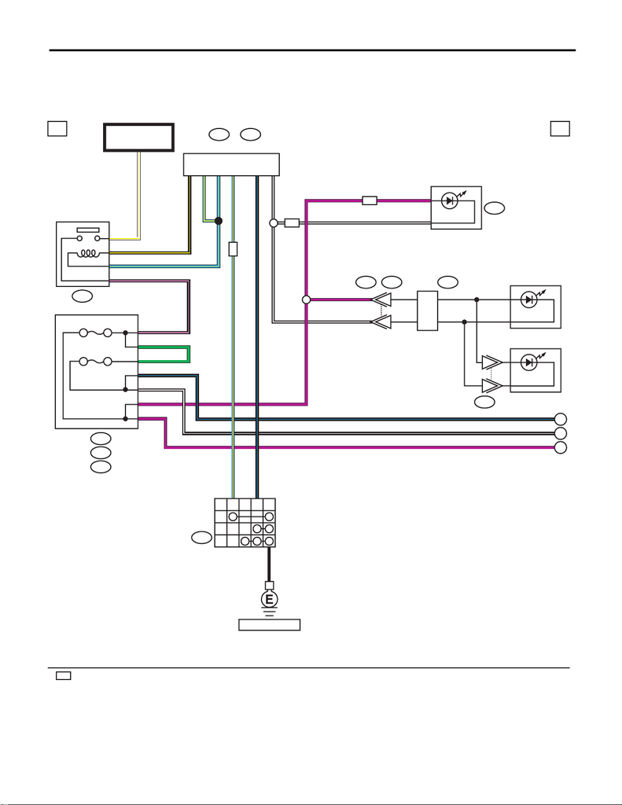

WI-115

Clearance Light and Illumination Light System

WIRING SYSTEM

12.Clearance Light and Illumination Light System

A: WIRING DIAGRAM

1. ENGINE TYPE FA

WI-44315

1a 1a

5

6

4

1

i5

A:

R168

B:

B52

C:

B358

ST1B68

B225

B281

B:

B280

A:

C

A

B/W

B8

G

B/L

V

V

A11

B/P

G

C21

C20

C4

C5

B/W

B/W

B12

B/LC17

F/B

2

B/W

V

B/W

ST5

ST3

10

11

V

1

B/P

B/Y

L/Y

13

11

10

12

L/Y A3

L/Y B19

B/Y A16

W/Y

L/O B16

CVT

V

CVT

B

L/O19

B/L B17B/L18

B71

OFF

1

AUTO

2

12

B

AL

AL

No. 14 10A

No. 16 7.5A

MB-32

M/B FUSE NO. 15

(B)

BODY INTEGRATED UNIT

TAIL & ILLUMINATION

RELAY

SATELLITE SWITCH

ILLUMI. LIGHT

STEERING SWITCH

ILLUMI. LIGHT

SELECT LEVER ILLUMI.

ROLL

CONNECTOR

COMBINATION

SWITCH

(LIGHTING

SWITCH)

REF. TO GND [b]

: WITH AUTO LIGHT

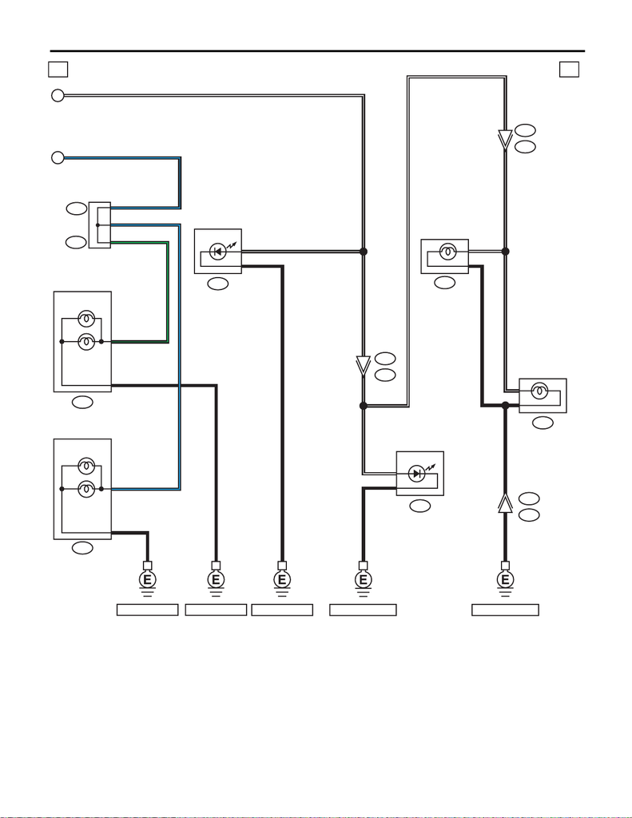

WI-116

Clearance Light and Illumination Light System

WIRING SYSTEM

WI-44316

1b 1b

5

6

1

A

B

2

4

B

B/W

B/W

R60

R24

B/WB

R60

R24

B

R81

R82

B/W

B/W

R76

1

B/WB

2

R77

B/W

B

B/W

B/L

R26

F125

4

B/G

F126

2

B/L

B/L

B/G

B/L

B360

B

B

B

B

B

R28

1

2

B

4

2

2

4

B

B/W

C7

B2

B1

C:

F109

B:

FRONT COMBINATION

LIGHT RH

REF. TO GND [h]

REF. TO GND [h]

REAR COMBINATION

LIGHT LH

THROUGH JOINT

CONNECTOR

FRONT COMBINATION

LIGHT LH

REAR COMBINATION

LIGHT RH

LICENSE PLATE

LIGHT RH

LICENSE PLATE

LIGHT LH

SIDE MARKER

LIGHT

CLEARANCE

LIGHT

SIDE MARKER

LIGHT

CLEARANCE

LIGHT

REF. TO GND [f]

REF. TO GND [a]

REF. TO GND [a]

TAIL LIGHT

TAIL LIGHT

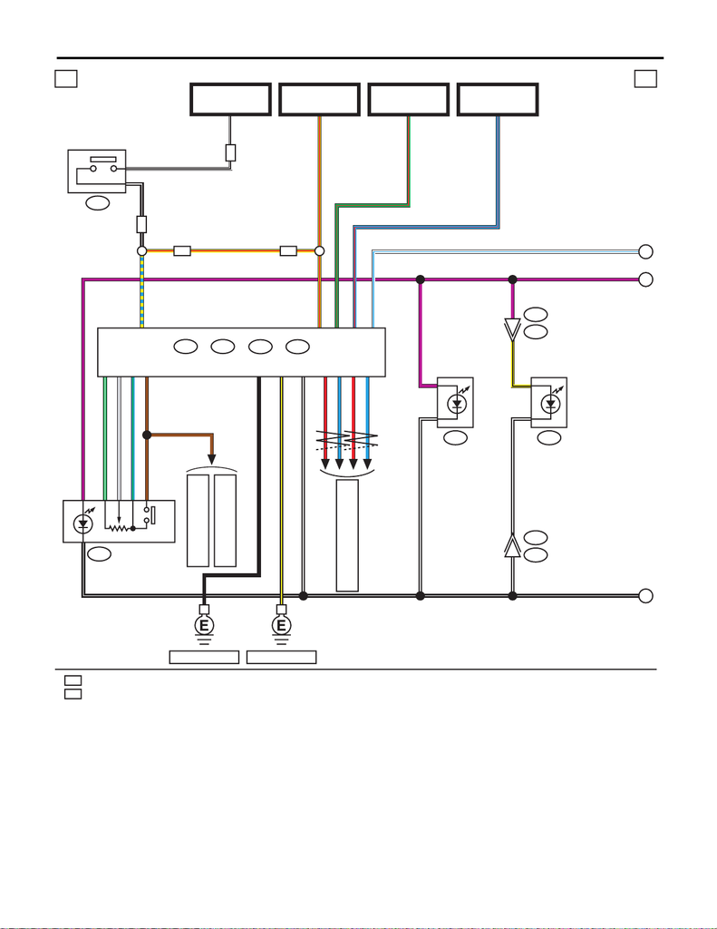

WI-117

Clearance Light and Illumination Light System

WIRING SYSTEM

WI-44317

1c 1c

27

28

B555

B280 B281

B:A:

i84

C:

i171

D:

D149

F

D

WP

OP

OP

WP

D84

i101

i101

D84

OP

E

3

A32

B/W C16

R B20

L B28

R C27

B/Y A1

BC1

L C35

BR C21

L/G D28

G/W

GR

D12

D22

i79

1BR

BR

6 L/G

5GR

4 G/W

2VB/W

B3 G/R

Y/R

C6 W/L

W/L

V

Y/R

G/R

i22

4

B/W

1

V

A4

W/B

B/W

B/W

1

2

1

15

16

B/WB/WB/W

B7 L/R

L/R

1

Y/B

V

B/W

WP

: WITH PUSH BUTTON START

: WITHOUT PUSH BUTTON START : B/W

WITH PUSH BUTTON START : Y/R

MB-29

M/B FUSE NO. 8

(B)

REMOTE CONTROL

MIRROR SWITCH

FB-38

F/B FUSE NO. 12

(IG)

FB-29

F/B FUSE NO. 31

(ACC)

MB-28

M/B FUSE NO. 14

(B)

KEY WARNING

SWITCH

REF. TO NAVIGATION

SYSTEM [1d]

REF. TO AUDIO SYSTEM

[1a] [3a]

REF. TO CAN COMMUNICATION

SYSTEM [b]

HAZARD

SWITCH

BRIGHT

SWITCH

ILLUMINATION

CONTROL SWITCH

: WITHOUT PUSH BUTTON START

BODY INTEGRATED UNIT

REF. TO GND [c]REF. TO GND [e]

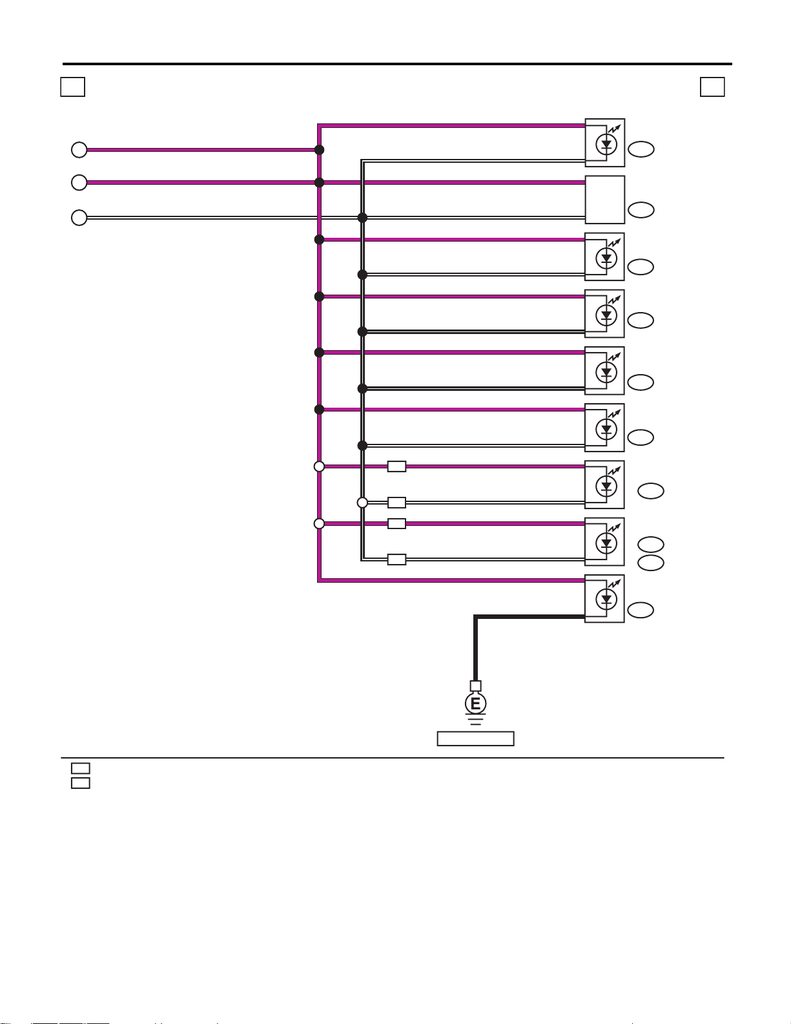

WI-118

Clearance Light and Illumination Light System

WIRING SYSTEM

WI-44318

1d 1d

WN

ON

ON

i85

A:

i50

A:

i131

B:

i88

i234

i7

WN

i28

C

E

F

ON

WN

A1

A2

A10

B5

37

35

4

3

1

4

B/W

B/W

V

i23

2

1B

V

B/W

B/W

V

B/W

V

V

i13

4

1B/W

B/WB/WB/WB/WB/W

V

VVVVVVV

4

1B/W

V

i9

2

1B/W

V

V

V

V

B/W

B

OP CONNECTOR

(FOG LIGHT SWITCH)

POCKET LIGHT

MFD SWITCH

TRUNK LID

OPENER SWITCH

VDC OFF SWITCH

ILLUMI. LIGHT

A/C CONTROL

PANEL

NAVIGATION

UNIT

: WITH NAVIGATION

: WITHOUT NAVIGATION

AUDIO

GLOVE BOX

ILLUMI. LIGHT

REF. TO GND [e]

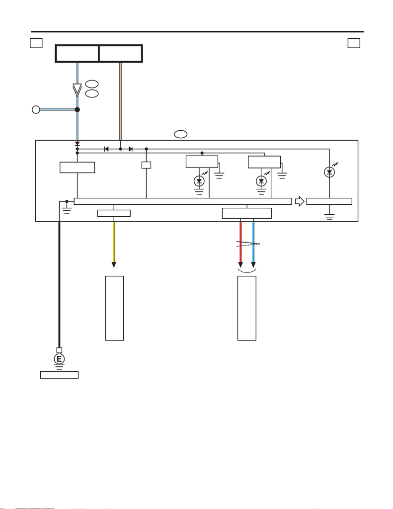

WI-119

Clearance Light and Illumination Light System

WIRING SYSTEM

WI-44319

1e 1e

3

i10

D

B551

i229

40 W/L W/L

W/L

20 BR/W

B38

Y28

W/L

I/F

BR/W

R33

L32

B

FB-12

F/B FUSE NO. 2

(IG)

FB-18

F/B FUSE NO. 7

(B)

DRIVE CIRCUIT

MICRO COMPUTER

CAN TRANSCEIVER &

RECEIVER

DRIVE CIRCUIT

(DIMMER)

DRIVE CIRCUIT

(DIMMER)

DRIVE CIRCUIT

POWER SUPPLY

CIRCUIT

HILL START ASSIST

PLATE ILLUMI.

LIGHT

INDICATOR

NEEDLE

ILLUMI. LIGHT

REF. TO GND [e]

COMBINATION METER

REF. TO CAN COMMUNICATION

SYSTEM [b]

REF. TO MULTI-FUNCTION

DISPLAY (MFD) SYSTEM [b]

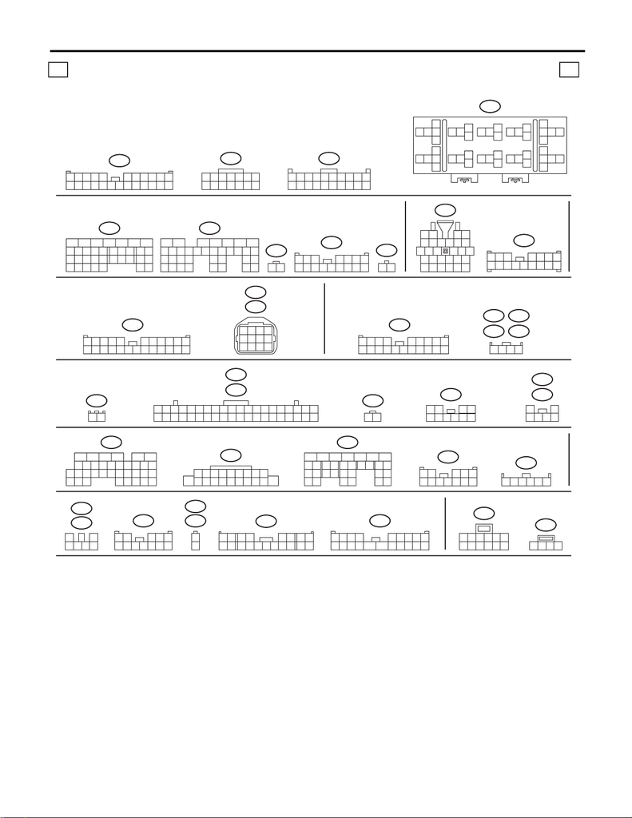

WI-120

Clearance Light and Illumination Light System

WIRING SYSTEM

LIST OF CONNECTORS

RELAY HOLDER

1f 1f

B280

B52

B281

D149

F126

F125

i131

i171

i5

A:

C:

B:

D84

i84

i10

i88

B358

F109

i85

i229

i234

i23

B225

B:

i79

B555

B360

R28

R26

B68

B71

(GR)

(GR)

C:

i50

A:

D:

C:

B:

A:

R60

i9

A:

R77

R76

(GR)

3412 89

10 11

12 13 14 15 16 17 18 19 20 21 22 23 24

567

3

42

156

7

13 1411

12

9

10

8

123456789

10

11 12 13 14 15 16 17 18 19 20

10 11

12

13

14 15

16

18

19 21 22

20

17

24

5

3

17

9

8

6

32 33

34

35

28262423

25

27

29

30

31

36 37

38

40

41 43 44

42

39

18

2719 20 21 22

23

26

24

25

28 29 3332 3430 31

98

15

1413121110

17

16

1234567

5672134

29

10 11 12 13 14 15

2524

16

30

98

17 18 19

20

28

21 22 23

3231

26 27

33 34 35

21

123 4567

89

10 11 12 13 14 15 16

12

19

18

20 21 22

1514131211

1

3

24

5

7

6

98

10

17

25

24

26 27 2823

16

12

3

4

567

89

10 11 12

14 15 1613

3412 89

10 11

12 13 14 15 16 17 18 19 20 21 22 23 24

567

1234

5678

9

10 11 12

89

19 20

1234 567

10 11 12 13 14 15 16 17 18

21

11 12

9

10

7856341

2

15 1613 14 19

18

20

21 22 23 24 26

25

27 28 29 30 31 32 33 34 35 36 37 38 39 40

17

63451

2

21

12

34

56789

10

5634

21

19

18

21

20

2322 24 25 26

17

1

23

4

56

27

28 29 30

31 32 33 34 35

798

151413121110 16

19

18

20

132

4

5

7

6

98

1514131211 1716

10

19

18

20 21

22

23

26

24

25

27

28 29

30 31

98

15

1413121110

17

16

1234567

12 345

6789

10 11 12

5

6

34

2112345

6789

10 11 12

1

2

1

9

234 5678

10 11 12 14 15 16 17 18 1913

B:

R168

1234

56789

10 11 12 13 14 15 16 17 18 19 20

ST3

2

1

89

5

12

6

7

34

1110

ST5

3

421

WI-44320

(B)

R82

i22

i7

(GR)

i28

(GR)

2143

(GR)

(GR)

i13

21

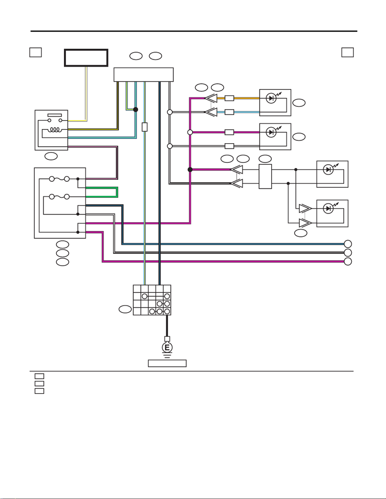

WI-121

Clearance Light and Illumination Light System

WIRING SYSTEM

2. ENGINE TYPE EJ

WI-44322

2a 2a

5

6

4

1

i5

A:

R168

B:

B52

C:

B358

ST1B68

B225

B281

B:

B280

A:

B

C

A

B/W

B8

G

B/L

V

V

A11

B/P

G

C21

C20

C4

C5

B/W

B/W

B12

B/LC17

F/B

2

B/W

V

B/W

ST5

ST3

10

11

V

1

B/P

B/Y

L/Y

13

11

10

12

L/Y A3

L/Y B19

B/Y A16

W/Y

L/O B16

OP

V

OP

AD14

7

SB

O

B/W

V

2

WP

WP

B71

L/O19

B/L B17B/L18

12

B

10

4

AD13B4

OFF

1

AUTO

2

AL

WP

OP

AL

No. 14 10A

No. 16 7.5A

MB-32

M/B FUSE NO. 15

(B)

BODY INTEGRATED UNIT

TAIL & ILLUMINATION

RELAY

SATELLITE SWITCH

ILLUMI. LIGHT

STEERING SWITCH

ILLUMI. LIGHT

SELECT LEVER ILLUMI.

STI ILLUMINATION

ROLL

CONNECTOR

COMBINATION

SWITCH

(LIGHTING

SWITCH)

REF. TO GND [b]

: WITH AUTO LIGHT

: WITHOUT PUSH BUTTON START

: WITH PUSH BUTTON START

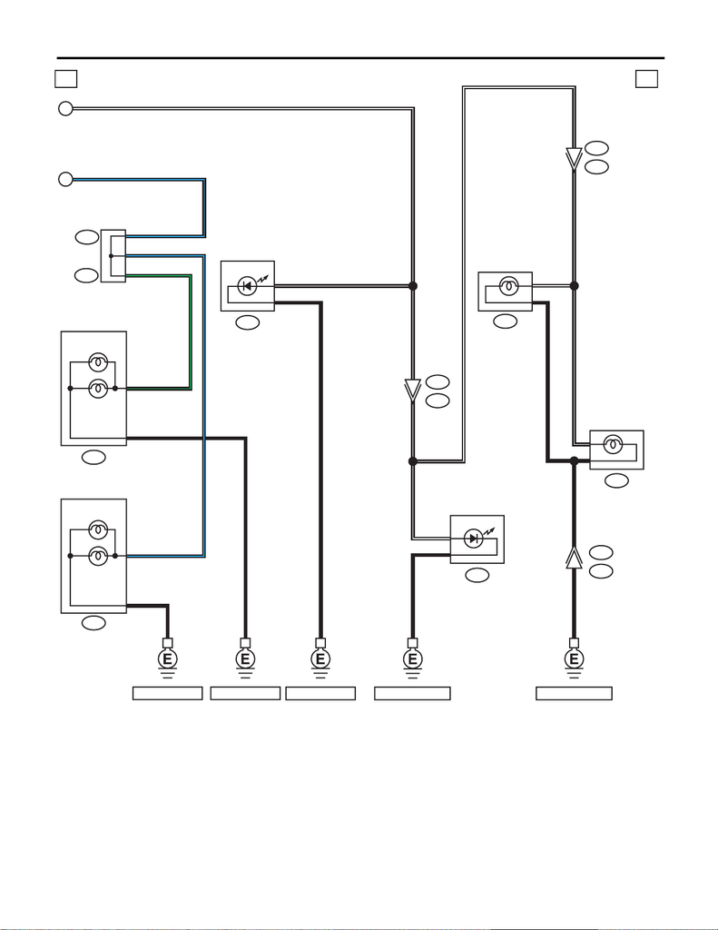

WI-122

Clearance Light and Illumination Light System

WIRING SYSTEM

WI-44323

2b 2b

6

1

A

B

2

4

B

B/W

B/W

R60

R24

B

R60

R24

R81

R82

B/W

B/W

R76

1

B/WB

2

R77

B/W

B

B/W

B/L

R26

F125

4

B/G

F126

2

B/L

B/L

B/G

B/L

B360

B

B

B

B

B

R28

1

2

B

4

2

2

4

B

B/W

C7

B2

B1

C:

F109

B:

5

FRONT COMBINATION

LIGHT RH

REF. TO GND [h]

REF. TO GND [h]

REAR COMBINATION

LIGHT LH

THROUGH JOINT

CONNECTOR

FRONT COMBINATION

LIGHT LH

REAR COMBINATION

LIGHT RH

LICENSE PLATE

LIGHT RH

LICENSE PLATE

LIGHT LH

SIDE MARKER

LIGHT

CLEARANCE

LIGHT

SIDE MARKER

LIGHT

CLEARANCE

LIGHT

REF. TO GND [f]

REF. TO GND [a]

REF. TO GND [a]

TAIL LIGHT

TAIL LIGHT

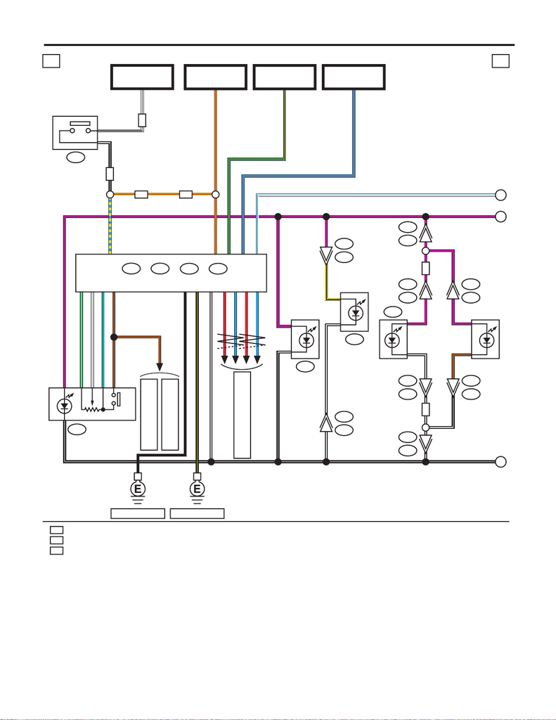

WI-123

Clearance Light and Illumination Light System

WIRING SYSTEM

WI-44324

2c 2c

27

28

6

7

7

10

B555

B280 B281

B:A:

i84

C:

i171

D:

D149

F

D

WP

OP

OP

WP

D84

i101

i101

D84

SH

SH

SH

OP

E

R34

AD6

2

i53

R98

R33

AD10

AD6

R34

11

R98

i53

AD10

R33

3

A32

B/W C16

R B20

L B28

R C27

L C35

BR C21

L/G D28

G/W

GR

D12

D22

i79

1BR

BR

6 L/G

5GR

4 G/W

2VB/W

B3 G/R

Y/R

C6 W/L

W/L

V

V

Y/R

G/R

i22

4

B/W

1

V

A4

W/B

B/W

B/W

1

2

1

15

16

B/WB/WB/WB/W

B7 L/R

L/R

1

Y/B

V

B/W

AD8

6

5

WP

B/W

B/W

B/W

BR

V

VV

B/Y A1

BC1

: WITH PUSH BUTTON START

SEAT HEATER

SWITCH

: WITHOUT PUSH BUTTON START : B/W

WITH PUSH BUTTON START : Y/R

MB-29

M/B FUSE NO. 8

(B)

REMOTE CONTROL

MIRROR SWITCH

FB-38

F/B FUSE NO. 12

(IG)

FB-29

F/B FUSE NO. 31

(ACC)

MB-28

M/B FUSE NO. 14

(B)

MULTI SELECT

SWITCH (DCCD)

KEY WARNING

SWITCH

REF. TO NAVIGATION

SYSTEM [2d]

REF. TO AUDIO SYSTEM

[2a] [4a]

REF. TO CAN COMMUNICATION

SYSTEM [b]

HAZARD

SWITCH

BRIGHT

SWITCH

ILLUMINATION

CONTROL SWITCH

: WITHOUT PUSH BUTTON START

: WITH SEAT HEATER

BODY INTEGRATED UNIT

REF. TO GND [c]REF. TO GND [e]

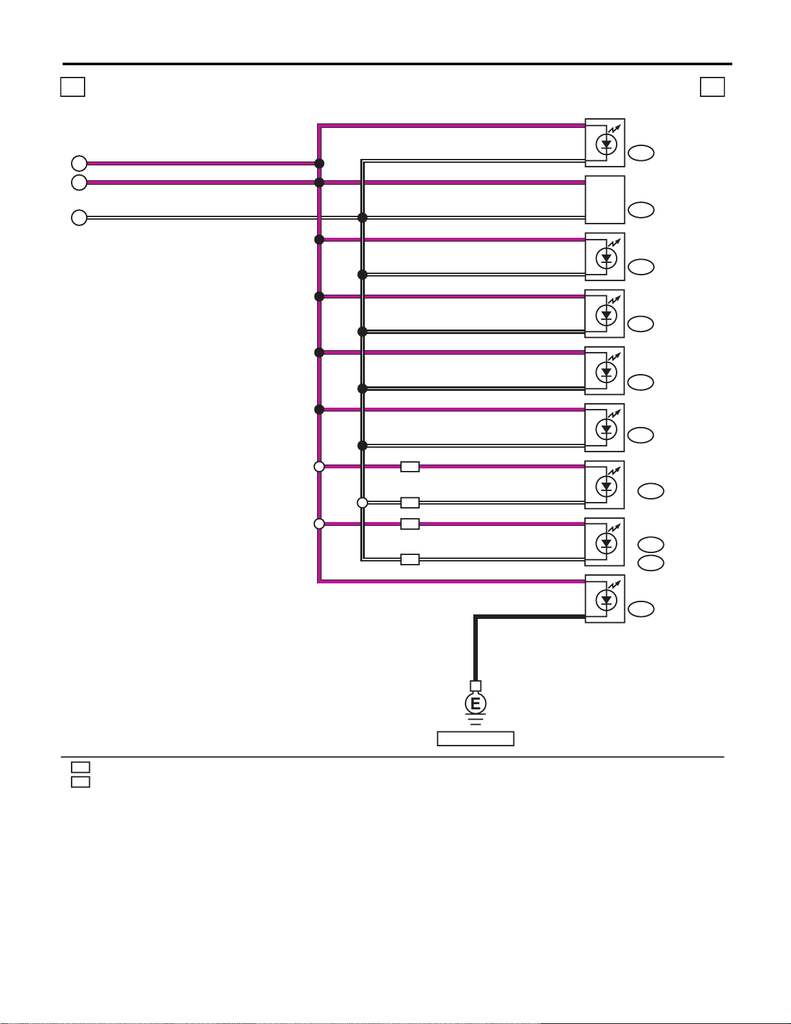

WI-124

Clearance Light and Illumination Light System

WIRING SYSTEM

WI-44325

2d 2d

WN

WN

ON

ON

i85A:

i50A:

i131B:

i88

i234

i7

i28

C

E

F

ON

WN

A1

A2

A10

B5

37

35

4

3

1

4

B/W

B/W

V

B/W

B/W

V

B/W

V

V

VVVVVVV

4

1B/W

V

i9

2

1B/W

V

i13

4

1B/W

B/WB/WB/WB/WB/W

V

i23

2

1B

V

V

AUDIO

V

V

B/W

B

OP CONNECTOR

(FOG LIGHT SWITCH)

POCKET LIGHT

TRUNK LID

OPENER SWITCH

GLOVE BOX

ILLUMI. LIGHT

MFD SWITCH

VDC OFF SWITCH

ILLUMI. LIGHT

A/C CONTROL

PANEL

NAVIGATION

UNIT

: WITH NAVIGATION

: WITHOUT NAVIGATION

REF. TO GND [e]

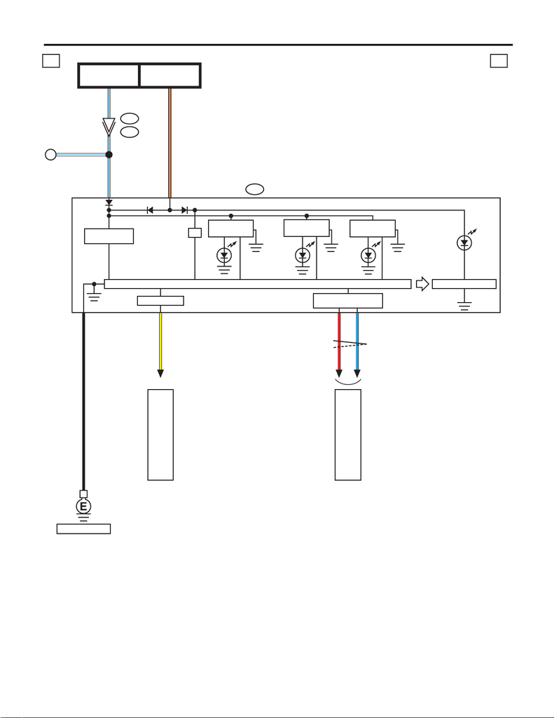

WI-125

Clearance Light and Illumination Light System

WIRING SYSTEM

WI-44326

2e 2e

3

i10

D

B551

i229

40 W/L W/L

W/L

20 BR/W

B38

Y28

W/L

I/F

BR/W

R33

L32

B

FB-12

F/B FUSE NO. 2

(IG)

FB-18

F/B FUSE NO. 7

(B)

DRIVE CIRCUIT

MICRO COMPUTER

CAN TRANSCEIVER &

RECEIVER

DRIVE CIRCUIT

(DIMMER)

DRIVE CIRCUIT

(DIMMER)

DRIVE CIRCUIT

(DIMMER)

DRIVE CIRCUIT

POWER SUPPLY

CIRCUIT

HILL START ASSIST

PLATE ILLUMI.

LIGHT

STI LOGO

INDICATOR

NEEDLE

ILLUMI. LIGHT

REF. TO GND [e]

COMBINATION METER

REF. TO CAN COMMUNICATION

SYSTEM [b]

REF. TO MULTI-FUNCTION

DISPLAY (MFD) SYSTEM [b]

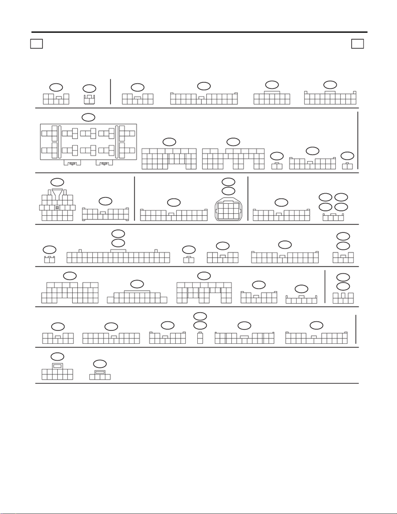

WI-126

Clearance Light and Illumination Light System

WIRING SYSTEM

LIST OF CONNECTORS

RELAY HOLDER

2f 2f

B280

B52

B281

D149

F126

F125

i131

i171

i5

A:

C:

B:

D84

i84

i10

B358

F109

i85

i88

i22

i23

i234

B225

B:

i79

B555

B360

R28

R26

B68

B71

(GR)

(GR)

i7

(GR)

(GR)

i229

i28

(GR)

i9

C:

i50

i53

A:

D:

C:

B:

A:

A:

R77

R76

(B)

R33

R34

R60

R82

(GR)

B4

(B)

8765

21

10

9

43

3412 89

10 11

12 13 14 15 16 17 18 19 20 21 22 23 24

567 3

42

156

7

13 1411

12

9

10

8

123456789

10

11 12 13 14 15 16 17 18 19 20

10 11

12

13

14 15

16

18

19 21 22

20

17

24

5

3

17

9

8

6

32 33

34

35

28262423

25

27

29

30

31

36 37

38

40

41 43 44

42

39

18

2719 20 21 22

23

26

24

25

28 29 3332 3430 31

98

15

1413121110

17

16

1234567

5672134

29

10 11 12 13 14 15

2524

16

30

98

17 18 19

20

28

21 22 23

3231

26 27

33 34 35

21

123 4567

89

10 11 12 13 14 15 16

12

19

18

20 21 22

1514131211

1

3

24

5

7

6

98

10

17

25

24

26 27 2823

16

12

3

4

567

89

10 11 12

14 15 1613

3412 89

10 11

12 13 14 15 16 17 18 19 20 21 22 23 24

567

1234

5678

9

10 11 12

89

19 20

1234 567

10 11 12 13 14 15 16 17 18

2143

21

11 12

9

10

7856341

2

15 1613 14 19

18

20

21 22 23 24 26

25

27 28 29 30 31 32 33 34 35 36 37 38 39 40

17

63451

2

21

12

34

56789

10

3412 89

10 11

12 13 14 15 16 17 18 19 20 21 22 23 24

567

5634

21

19

18

21

20

2322 24 25 26

17

1

23

4

56

27

28 29 30

31 32 33 34 35

798

151413121110 16

19

18

20

132

4

5

7

6

98

1514131211 1716

10

19

18

20 21

22

23

26

24

25

27

28 29

30 31

98

15

1413121110

17

16

1234567

12 345

6789

10 11 12

5

6

34

21

12

34

56789

10

123

161514

546789

17 18 19 2013121110

12 345

6789

10 11 12

1

2

1

9

234 5678

10 11 12 14 15 16 17 18 1913

AD8

AD14

12 3

45678

12

B:

R168

1234

56789

10 11 12 13 14 15 16 17 18 19 20

ST3

2

1

89

5

12

6

7

34

1110

ST5

3

421

WI-44327

(GR)

i13

21